# Decision Tree Fundamentals

## Why Tree-Based Methods? Real-World Context

**The Limitations We’ve Seen:**

- **Linear regression:** Assumes additive, linear relationships
- **Logistic regression:** Linear decision boundaries
- **k-NN:** Makes predictions but can’t explain “why” (black box)
- **Real world:** Complex interactions, non-linear patterns, need for interpretable rules

**What if relationships look like this?**

- High income + Low debt → Approve loan
- Young age + High risk job → Higher insurance premium
- Chest pain + Abnormal stress test → High heart disease risk

**Enter Decision Trees:**

- **Human-like reasoning:** Series of yes/no questions
- **Automatic interactions:** No need to specify X₁ × X₂ terms
- **Mixed data types:** Handle numerical and categorical naturally
- **Interpretable rules:** Can explain decisions to stakeholders (major advantage over k-NN)
- **Global model:** One set of rules for all predictions (vs k-NN’s local neighborhoods)

**This Week’s Journey:** Today we learn how trees work, then build toward ensemble methods that combine many trees for superior performance while maintaining interpretability.

## Motivating Example: Predicting Baseball Salaries

Let’s predict baseball player salaries using just two predictors: **Years** (experience) and **Hits** (performance).

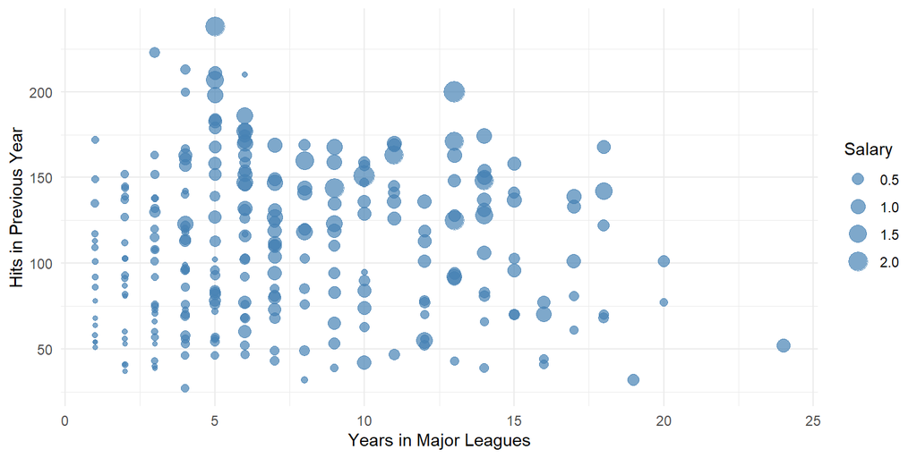

**The Challenge:** Can you see patterns in where high-salary players (big dots) cluster?  
**Question:** What simple rules might divide players into salary groups?

## Building Our First Regression Tree

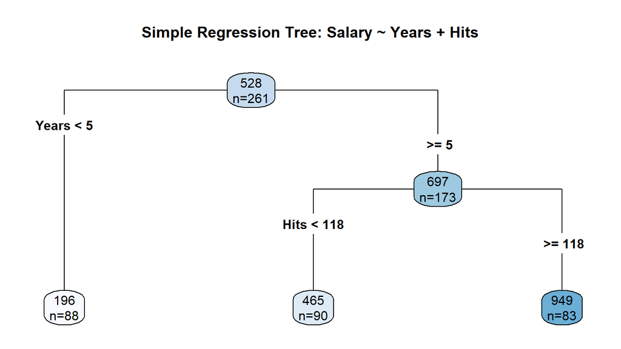

- **Root split:** Years < 5 (rookies vs experienced players)
- **Second split:** Among experienced players, Hits < 118
- **Three salary groups:** Rookies, experienced/low-hits, experienced/high-hits

## Visualizing the Tree’s Solution

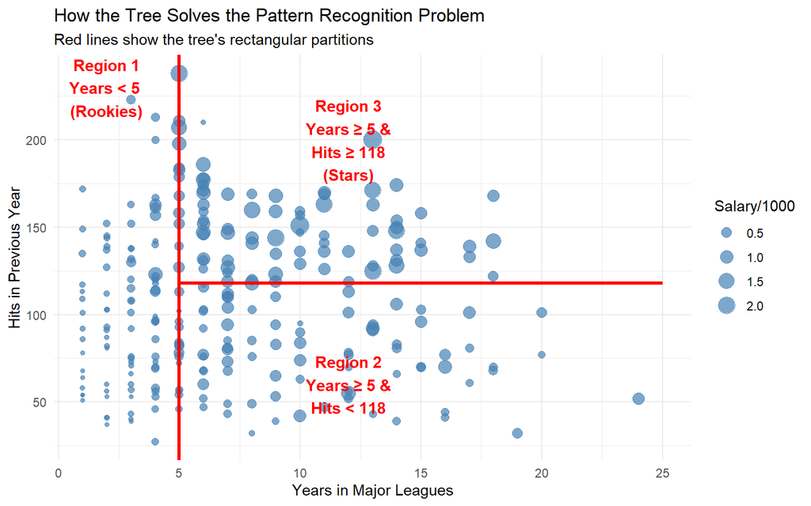

## How Decision Trees Work: The Algorithm

**Decision Trees** use **recursive binary splitting** to partition the predictor space:

**For Regression Trees:**

1. **At each step:** Find predictor \(X_j\) and cutpoint \(s\) that minimizes RSS: \[\sum_{i: x_i \in R_1} (y_i - \hat{y}_{R_1})^2 + \sum_{i: x_i \in R_2} (y_i - \hat{y}_{R_2})^2\]
2. **Split regions:** \(R_1 = \{X|X_j < s\}\) and \(R_2 = \{X|X_j \geq s\}\)
3. **Predict:** Use mean of training observations in each terminal region

**Tree Algorithm Process:**

- **Top-down:** Start with all data, recursively split
- **Greedy:** Choose best split at each step (not globally optimal)
- **Binary:** Each split creates exactly two branches
- **Stopping criteria:** Min observations per node, complexity parameter, max depth

## Reading Tree Output: Decoding the Results

Let’s examine the actual output from our Hitters tree to understand what R is telling us:

```
## n= 261
##
## node), split, n, deviance, yval
##       * denotes terminal node
##
## 1) root 261 50624070 528.3570
##   2) Years< 4.5 88  2595031 196.3352 *
##   3) Years>=4.5 173 33393450 697.2467
##     6) Hits< 117.5 90  5312120 464.9167 *
##     7) Hits>=117.5 83 17955720 949.1708 *
```

**Key Insights from the Numbers:**

- **Sample sizes:** Node 2 (88) + Node 6 (90) + Node 7 (83) = 261 total ✓
- **Salary progression:** $196k → $465k → $949k
- **Deviance decreases** as we split (improvement in fit)
- **Asterisks** mark terminal nodes (leaves) where predictions are made

## What about classification?

**Two Types of Decision Trees Based on Outcome Variable:**

**Regression Trees** (What we just saw):

- **Outcome:** Continuous variable (salary, price, temperature)
- **Prediction:** Mean of observations in each leaf node
- **Splitting criterion:** Minimize RSS (Residual Sum of Squares)
- **Example:** Predicting baseball player salaries

**Classification Trees** (Coming up next):

- **Outcome:** Categorical variable (yes/no, pass/fail, low/medium/high)
- **Prediction:** Most common class in each leaf node
- **Splitting criterion:** Minimize node impurity (Gini Index or Cross-entropy)
  - **Gini Index:** \(G = \sum_{k=1}^{K} \hat{p}_{mk}(1 - \hat{p}_{mk})\)
  - **Cross-entropy:** \(D = -\sum_{k=1}^{K} \hat{p}_{mk} \log \hat{p}_{mk}\)
- **Example:** Predicting credit card default (Default vs No Default)

## Understanding the Gini Index

**The Goal:** Create nodes that are as “pure” as possible (contain mostly one class)

- Example: What question to ask if I want to predict `econ` major?

**Gini Index Formula (Simplified for Two Classes):**

For binary classification with classes “yes” and “no”:

\[G = 2p(1-p)\]

- where \(p\) = proportion of “yes” observations
- and \((1-p)\) = proportion of “no” observations

**Intuitive Examples:**

```
##              Scenario Prop_Yes Prop_No Gini_Index
## 1      Perfect Purity      0.0     1.0       0.00
## 2      Worst Impurity      0.5     0.5       0.50
## 3 Moderate Impurity 1      0.7     0.3       0.42
## 4 Moderate Impurity 2      0.2     0.8       0.32
```

- Goal is to find splits that have the smallest \(G\)

## Classification Trees: Default Credit Example

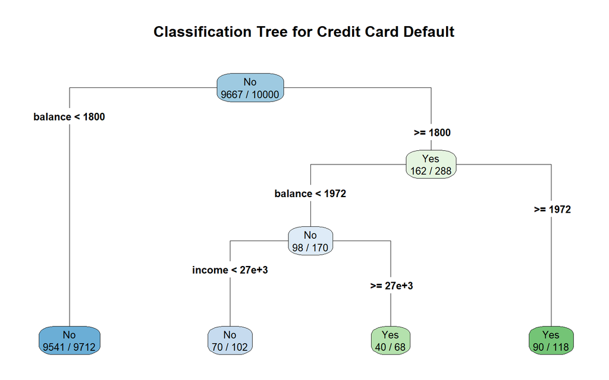

**Most Important Variables:** Balance and income appear to be key predictors

## Classification Performance Metrics

Decision trees follow the same evaluation framework as logistic regression, k-NN, or any other classifier:

1. **Split data** into training and test sets
2. **Train model** on training data
3. **Make predictions** on test data
4. **Build confusion matrix** from predictions vs actual

```
##          Actual
## Predicted   No  Yes
##       No  2860   71
##       Yes   26   43
```

1. **Calculate performance metrics** from confusion matrix

```
##                 Metric Value
## 1             Accuracy 0.968
## 2            Precision 0.623
## 3 Sensitivity (Recall) 0.377
## 4          Specificity 0.991
## 5             F1 Score 0.470
```

## Tree Complexity and When Trees Struggle

- Trees can easily overfit because they are so flexible

```
##      Tree_Type Nodes Accuracy Precision Sensitivity Specificity F1_Score
## 1  Simple Tree     6    0.968     0.623       0.377       0.991    0.470
## 2 Complex Tree   247    0.952     0.376       0.412       0.973    0.393
```

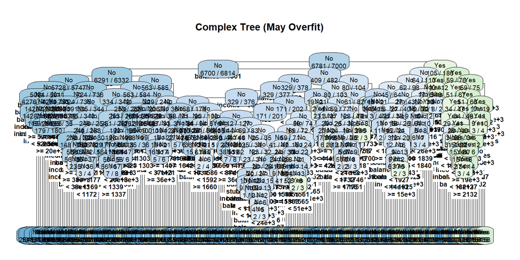

## Tree Algorithms: Stopping Criteria

**rpart.control() Parameters:**

- **cp:** Complexity parameter (minimum improvement required for split)
- **minsplit:** Minimum observations required to attempt split
- **maxdepth:** Maximum tree depth
- **Tradeoff:** Early stopping vs overfitting

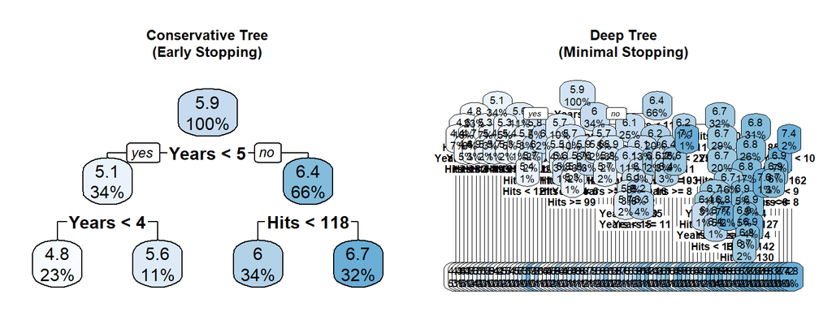

## Understanding Tree Predictions

**How rpart Makes Predictions:**

- Each internal node tests one variable against a threshold
- Follow the appropriate branch based on the test result
- Continue until reaching a terminal (leaf) node
- Use the majority class (or mean) in that leaf as the prediction

```r
set.seed(124)
# Show how rpart makes predictions for specific observations
# Take first 5 test observations from Default dataset
sample_obs <- default_test %>% filter(balance>1500) %>% slice_sample(n = 5)
sample_predictions <- predict(default_tree_train, sample_obs, type = "class")
sample_probs <- predict(default_tree_train, sample_obs, type = "prob")
```

```
##   Balance Income Predicted Prob_No Actual
## 1    1593  73554        No   0.983     No
## 2    2134  19676       Yes   0.224     No
## 3    1971  37905       Yes   0.224     No
## 4    1661  53754        No   0.983     No
## 5    1881  16580        No   0.703    Yes
```

## Tree Implementation in R: Practical Guide

```r
# Basic syntax
rpart(formula, data, method, control = rpart.control())

# Method options:
# "anova" - regression trees (continuous outcome)
# "class" - classification trees (categorical outcome)

# Controlling complexity
rpart.control(cp = 0.01,        # Complexity parameter (lower = more complex)
              minsplit = 20,     # Min observations to attempt split
              maxdepth = 10)     # Maximum tree depth

# Visualization
rpart.plot(tree_model, type = 4, extra = 2)  # Professional tree plots

# Predictions
predict(tree_model, newdata, type = "class") # Classifications
predict(tree_model, newdata, type = "prob")  # Class probabilities
predict(tree_model, newdata)                 # Regression (default)
```

## Trees vs Linear Models: When to Use Each

- **Linear separable data:** Logistic regression excels with straight-line boundaries
- **Non-linear patterns:** Decision trees capture complex, rectangular regions naturally
- **Interpretability:** Trees provide if-then rules, logistic gives linear coefficients
- **This example:** Tree clearly outperforms logistic regression on non-linear boundary!

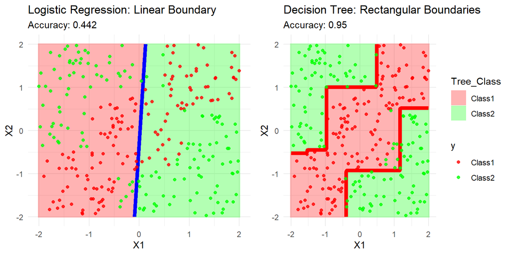

## Building Intuition: Manual Tree Construction

```r
# Calculate RSS for different potential splits on Years
years_splits <- c(2.5, 3.5, 4.5, 5.5, 6.5);rss_results <- numeric(length(years_splits))
for(i in seq_along(years_splits)) {
  split_val <- years_splits[i]
  # Split data
  left_group <- Hitters$LogSalary[Hitters$Years < split_val]
  right_group <- Hitters$LogSalary[Hitters$Years >= split_val]
  # Calculate RSS for each group
  left_rss <- sum((left_group - mean(left_group))^2)
  right_rss <- sum((right_group - mean(right_group))^2)
  # Total RSS
  rss_results[i] <- left_rss + right_rss
}
```

```
##   Years_Split Total_RSS   Best_Split
## 1         2.5    137.93
## 2         3.5    108.40
## 3         4.5    105.37  <-- MINIMUM
## 4         5.5    125.50
## 5         6.5    143.48
```

- Decision trees tests **all possible splits** and chooses the one that minimizes our criteria
- Very powerful algorithm but can be computationally intensive for large datasets

## Limitations of Single Decision Trees

**High Variance Problem:**

- Small changes in data can produce very different decision trees
- **Example:** Remove a few observations → completely different splits
- This makes decision trees **unstable** for prediction

**Other Limitations:**

- **Linear relationships:** Need many splits to approximate
- **Biased splits:** Favor predictors with more possible cut points
- **Overfitting:** Deep decision trees memorize training data

**Preview of Solutions:**

- **Day 16:** Pruning to reduce overfitting
- **Day 17:** Bootstrap aggregating (bagging) to reduce variance
- **Day 18:** Boosting to reduce bias